# Klasyfikacja binarna przelewów bankowych

## Autorzy:

##### Jakub Załuska 217319

##### Patryk Welkier 217409

##### Kuba Zalewski 217300

##### Karolina Trzaskulska 217485

```python
# Importowanie niezbędnych bibliotek
import numpy as np
import pandas as pd
import seaborn as sns
import matplotlib.pyplot as plt
```

# Streszczenie

# Słowa kluczowe

- Regresja logistyczna
- K najbliższych sąsiadów (KNN)
- drzewa decyzyjne
- F1-score
- SGDClassifier

# Przedmiot badania

## Opis i analiza danych

Wśród danych mamy 284807 obserwacji, z czego każda zawiera cechy niezależne takie jak: Time- Czas od pierwszej transakcji w sekundach, Amount- Kwota transakcji oraz V1-V28- wartości wynikające z transformacji PCA (Principal Component Analysis) (te cechy są utajnione) oraz cechę zależną Class, która oznacza, czy transakcja jest oszustwem, czy nie. W zbiorze danych przelewów oznaczonych klasą 1 (czyli oszustwo), mamy 492 (0.17%).

```python
# Importowanie danych z pliku CSV
data = pd.read_csv('creditcard.csv')
data.head()
```

|  | Time | V1 | V2 | V3 | V4 | V5 | V6 | V7 | V8 | V9 | ... | V21 | V22 | V23 | V24 | V25 | V26 | V27 | V28 | Amount | Class |
| --- | --- | --- | --- | --- | --- | --- | --- | --- | --- | --- | --- | --- | --- | --- | --- | --- | --- | --- | --- | --- | --- |
| 0 | 0.0 | -1.359807 | -0.072781 | 2.536347 | 1.378155 | -0.338321 | 0.462388 | 0.239599 | 0.098698 | 0.363787 | ... | -0.018307 | 0.277838 | -0.110474 | 0.066928 | 0.128539 | -0.189115 | 0.133558 | -0.021053 | 149.62 | 0 |
| 1 | 0.0 | 1.191857 | 0.266151 | 0.166480 | 0.448154 | 0.060018 | -0.082361 | -0.078803 | 0.085102 | -0.255425 | ... | -0.225775 | -0.638672 | 0.101288 | -0.339846 | 0.167170 | 0.125895 | -0.008983 | 0.014724 | 2.69 | 0 |
| 2 | 1.0 | -1.358354 | -1.340163 | 1.773209 | 0.379780 | -0.503198 | 1.800499 | 0.791461 | 0.247676 | -1.514654 | ... | 0.247998 | 0.771679 | 0.909412 | -0.689281 | -0.327642 | -0.139097 | -0.055353 | -0.059752 | 378.66 | 0 |
| 3 | 1.0 | -0.966272 | -0.185226 | 1.792993 | -0.863291 | -0.010309 | 1.247203 | 0.237609 | 0.377436 | -1.387024 | ... | -0.108300 | 0.005274 | -0.190321 | -1.175575 | 0.647376 | -0.221929 | 0.062723 | 0.061458 | 123.50 | 0 |
| 4 | 2.0 | -1.158233 | 0.877737 | 1.548718 | 0.403034 | -0.407193 | 0.095921 | 0.592941 | -0.270533 | 0.817739 | ... | -0.009431 | 0.798278 | -0.137458 | 0.141267 | -0.206010 | 0.502292 | 0.219422 | 0.215153 | 69.99 | 0 |

5 rows × 31 columns

```python
# Wyświetlenie liczby wierszy i kolumn w zbiorze danych
data.shape
```

```
(284807, 31)
```

```python
# Wyświetlenie informacji o danych, w tym typów danych w każdej kolumnie, liczby niepustych wartości i zajmowanej pamięci
data.info()
```

```
<class 'pandas.core.frame.DataFrame'>
RangeIndex: 284807 entries, 0 to 284806
Data columns (total 31 columns):
 #   Column  Non-Null Count   Dtype
---  ------  --------------   -----
 0   Time    284807 non-null  float64
 1   V1      284807 non-null  float64
 2   V2      284807 non-null  float64
 3   V3      284807 non-null  float64
 4   V4      284807 non-null  float64
 5   V5      284807 non-null  float64
 6   V6      284807 non-null  float64
 7   V7      284807 non-null  float64
 8   V8      284807 non-null  float64
 9   V9      284807 non-null  float64
```

[output cut: 23 more lines]

## Analiza liczby wystąpień wartości 0 i 1 w kolumnie 'Class'

##### 0 (nie oszustwo): 284,315 przypadków (99.83%)

##### 1 (oszustwo): 492 przypadków (0.17%)

```python
# Wyświetlenie liczby wystąpień wartości 0 oraz 1 w kolumnie 'Class'
print(data['Class'].value_counts())
```

```
Class
0    284315
1       492
Name: count, dtype: int64
```

```python
# Obliczenie i wyświetlenie proporcji wartości 0 i 1 w zbiorze danych
print(data['Class'].value_counts()/data.shape[0]*100)
```

```
Class
0    99.827251
1     0.172749
Name: count, dtype: float64
```

## Wizualizacja liczby wystąpień wartości 0 i 1 w kolumnie 'Class'

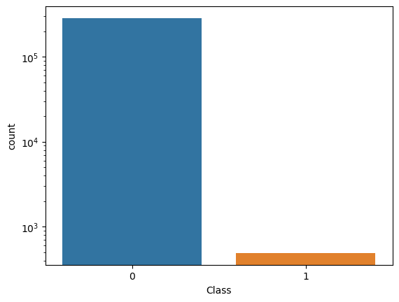

```python
import seaborn as sns
import matplotlib.pyplot as plt

# Utworzenie wykresu słupkowego, w skali logarytmicznej przedstawiającego liczby wystąpień wartości 0 i 1 w kolumnie 'Class'
sns.countplot(data,x = 'Class')
plt.yscale('log')
plt.show()
```

## Histogramy dla wszystkich kolumn w zbiorze danych

[output not shown]

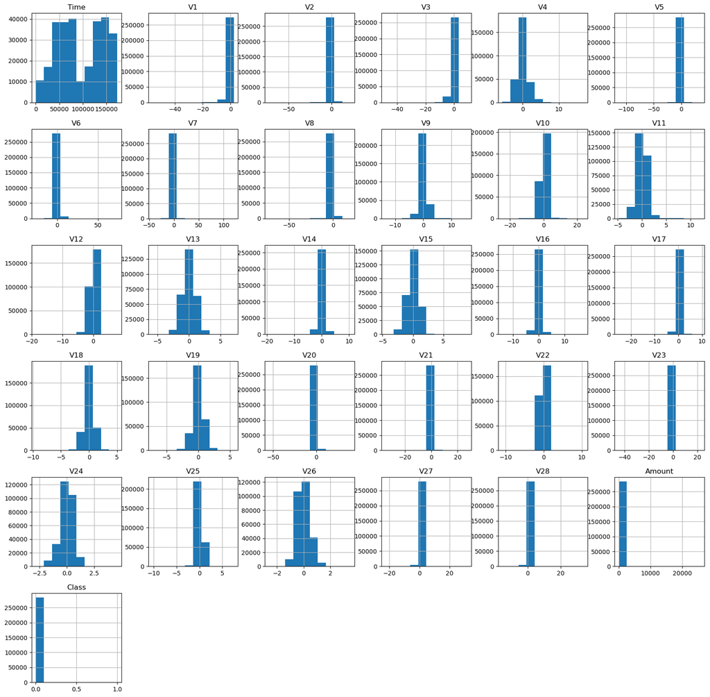

```python
# Utworzenie histogramów dla wszystkich kolumn w zbiorze danych
data.hist(figsize = (20,20))
```

## Macierz korelacji dla wszystkich kolumn liczbowych w zbiorze danych

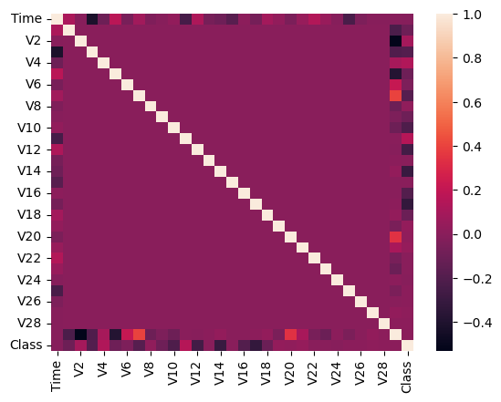

```python
# Utworzenie macierzy korelacji dla wszystkich kolumn liczbowych w zbiorze danych
sns.heatmap(data.corr(numeric_only= True))
```

```python
# Generowanie podsumowania statystycznego dla danych numerycznych, takich jak średnia, odchylenie standardowe, kwartyle, min i max
data.describe()
```

|  | Time | V1 | V2 | V3 | V4 | V5 | V6 | V7 | V8 | V9 | ... | V21 | V22 | V23 | V24 | V25 | V26 | V27 | V28 | Amount | Class |
| --- | --- | --- | --- | --- | --- | --- | --- | --- | --- | --- | --- | --- | --- | --- | --- | --- | --- | --- | --- | --- | --- |
| count | 284807.000000 | 2.848070e+05 | 2.848070e+05 | 2.848070e+05 | 2.848070e+05 | 2.848070e+05 | 2.848070e+05 | 2.848070e+05 | 2.848070e+05 | 2.848070e+05 | ... | 2.848070e+05 | 2.848070e+05 | 2.848070e+05 | 2.848070e+05 | 2.848070e+05 | 2.848070e+05 | 2.848070e+05 | 2.848070e+05 | 284807.000000 | 284807.000000 |
| mean | 94813.859575 | 1.168375e-15 | 3.416908e-16 | -1.379537e-15 | 2.074095e-15 | 9.604066e-16 | 1.487313e-15 | -5.556467e-16 | 1.213481e-16 | -2.406331e-15 | ... | 1.654067e-16 | -3.568593e-16 | 2.578648e-16 | 4.473266e-15 | 5.340915e-16 | 1.683437e-15 | -3.660091e-16 | -1.227390e-16 | 88.349619 | 0.001727 |
| std | 47488.145955 | 1.958696e+00 | 1.651309e+00 | 1.516255e+00 | 1.415869e+00 | 1.380247e+00 | 1.332271e+00 | 1.237094e+00 | 1.194353e+00 | 1.098632e+00 | ... | 7.345240e-01 | 7.257016e-01 | 6.244603e-01 | 6.056471e-01 | 5.212781e-01 | 4.822270e-01 | 4.036325e-01 | 3.300833e-01 | 250.120109 | 0.041527 |
| min | 0.000000 | -5.640751e+01 | -7.271573e+01 | -4.832559e+01 | -5.683171e+00 | -1.137433e+02 | -2.616051e+01 | -4.355724e+01 | -7.321672e+01 | -1.343407e+01 | ... | -3.483038e+01 | -1.093314e+01 | -4.480774e+01 | -2.836627e+00 | -1.029540e+01 | -2.604551e+00 | -2.256568e+01 | -1.543008e+01 | 0.000000 | 0.000000 |
| 25% | 54201.500000 | -9.203734e-01 | -5.985499e-01 | -8.903648e-01 | -8.486401e-01 | -6.915971e-01 | -7.682956e-01 | -5.540759e-01 | -2.086297e-01 | -6.430976e-01 | ... | -2.283949e-01 | -5.423504e-01 | -1.618463e-01 | -3.545861e-01 | -3.171451e-01 | -3.269839e-01 | -7.083953e-02 | -5.295979e-02 | 5.600000 | 0.000000 |
| 50% | 84692.000000 | 1.810880e-02 | 6.548556e-02 | 1.798463e-01 | -1.984653e-02 | -5.433583e-02 | -2.741871e-01 | 4.010308e-02 | 2.235804e-02 | -5.142873e-02 | ... | -2.945017e-02 | 6.781943e-03 | -1.119293e-02 | 4.097606e-02 | 1.659350e-02 | -5.213911e-02 | 1.342146e-03 | 1.124383e-02 | 22.000000 | 0.000000 |
| 75% | 139320.500000 | 1.315642e+00 | 8.037239e-01 | 1.027196e+00 | 7.433413e-01 | 6.119264e-01 | 3.985649e-01 | 5.704361e-01 | 3.273459e-01 | 5.971390e-01 | ... | 1.863772e-01 | 5.285536e-01 | 1.476421e-01 | 4.395266e-01 | 3.507156e-01 | 2.409522e-01 | 9.104512e-02 | 7.827995e-02 | 77.165000 | 0.000000 |
| max | 172792.000000 | 2.454930e+00 | 2.205773e+01 | 9.382558e+00 | 1.687534e+01 | 3.480167e+01 | 7.330163e+01 | 1.205895e+02 | 2.000721e+01 | 1.559499e+01 | ... | 2.720284e+01 | 1.050309e+01 | 2.252841e+01 | 4.584549e+00 | 7.519589e+00 | 3.517346e+00 | 3.161220e+01 | 3.384781e+01 | 25691.160000 | 1.000000 |

8 rows × 31 columns

# Korelacje

## Sprawdzenie liczby brakujących wartości w każdej kolumnie zbioru danych

Brak brakujących wartości w zbiorze danych.

```python
# Sprawdzenie liczby brakujących wartości w każdej kolumnie zbioru danych
data.isnull().sum()
```

```
Time      0
V1        0
V2        0
V3        0
V4        0
V5        0
V6        0
V7        0
V8        0
V9        0
V10       0
V11       0
V12       0
V13       0
V14       0
V15       0
V16       0
V17       0
V18       0
V19       0
V20       0
V21       0
V22       0
V23       0
V24       0
V25       0
V26       0
V27       0
V28       0
Amount    0
Class     0
dtype: int64
```

# Tworzenie zbioru testowego

```python
# Tworzenie zmiennych X i Y do podziału danych na zmienne niezależne (X) i zmienną zależną (Y)
X = data.drop('Class', axis = 1)
Y = data['Class']
Y
```

```
0         0
1         0
2         0
3         0
4         0
         ..
284802    0
284803    0
284804    0
284805    0
284806    0
Name: Class, Length: 284807, dtype: int64
```

```python
from sklearn.model_selection import train_test_split

# Podział danych na zestawy treningowe i testowe, gdzie X_train i Y_train są zestawami treningowymi, a X_test i Y_test są zestawami testowymi
X_train, X_test, Y_train, Y_test = train_test_split(X, Y, test_size = 0.2, random_state = 42)
Y_train = np.array(Y_train)
# Wyświetlenie liczby elementów w tablicy Y_train
Y_train.shape
```

```
(227845,)
```

```python
# Wyświetlenie liczby elementów w tablicy X_train. Liczba 227845 to ilość obserwacji w zbiorze treningowym
X_train.shape
```

```
(227845, 30)
```

# Transformacje danych

## Skalowanie

Używając StandardScaler, transformujemy dane tak, aby odchylenie standardowe wynosiło 1.

```python
from sklearn.preprocessing import StandardScaler
# Utworzenie obiektu scaler klasy StandardScaler do standaryzacji danych
scaler = StandardScaler()
# Standaryzacja danych treningowych
X_scaled_train = scaler.fit_transform(X_train)
X_scaled_test = scaler.fit_transform(X_test)
X_scaled_train
```

```
array([[ 1.02255459,  0.99785119, -0.22962626, ...,  0.11248883,
        -0.14374055, -0.30788875],
       [ 0.47128275, -0.205221  , -0.37821992, ..., -0.92189789,
        -0.43984143, -0.1670264 ],
       [ 1.15338663,  0.03655821,  0.49556347, ...,  0.51372993,
         0.21235767, -0.30004345],
       ...,
       [-0.31581527, -0.07533181,  0.59962034, ..., -0.3013968 ,
        -0.59571596, -0.33162078],
       [-0.1444891 , -1.50615534,  1.42172842, ...,  1.23673372,
         1.01755287, -0.34315338],
       [-0.38770656,  0.62923844, -0.47354037, ...,  0.00310728,
         0.11623211,  0.0961834 ]])
```

```python
# Wyświetlenie przeskalowanych dane treningowych
X_scaled_train_pd = pd.DataFrame(X_scaled_train)
X_scaled_train_pd
```

|  | 0 | 1 | 2 | 3 | 4 | 5 | 6 | 7 | 8 | 9 | ... | 20 | 21 | 22 | 23 | 24 | 25 | 26 | 27 | 28 | 29 |
| --- | --- | --- | --- | --- | --- | --- | --- | --- | --- | --- | --- | --- | --- | --- | --- | --- | --- | --- | --- | --- | --- |
| 0 | 1.022555 | 0.997851 | -0.229626 | -0.207385 | 0.234215 | -0.367791 | -0.064022 | -0.505889 | 0.030604 | 0.959955 | ... | -0.162507 | 0.324839 | 1.336699 | 0.084569 | -0.459802 | -0.084368 | -0.448942 | 0.112489 | -0.143741 | -0.307889 |
| 1 | 0.471283 | -0.205221 | -0.378220 | 1.027544 | -1.424101 | -0.078380 | 0.126364 | 0.013567 | -0.337559 | 0.035913 | ... | -0.608195 | -0.209797 | 0.583086 | 0.180620 | -1.658084 | -2.253352 | 0.750588 | -0.921898 | -0.439841 | -0.167026 |
| 2 | 1.153387 | 0.036558 | 0.495563 | -0.370033 | -0.500363 | 0.777856 | -0.268414 | 0.632710 | 0.098986 | -0.120484 | ... | 0.015283 | -0.429767 | -1.201892 | 0.132700 | 0.245102 | -0.825048 | 0.248488 | 0.513730 | 0.212358 | -0.300043 |
| 3 | -0.023638 | -0.273682 | 0.612684 | 1.156521 | 1.957021 | 0.359664 | 0.750211 | 0.680997 | -0.068094 | 0.337677 | ... | -0.328347 | 0.086416 | 0.613043 | -0.116294 | 0.740628 | -1.253870 | -0.374857 | -0.231400 | -0.197676 | 0.113600 |
| 4 | -0.255590 | -2.056777 | 1.145573 | -0.283165 | -0.019856 | -0.617403 | -0.358912 | -0.351206 | 1.105586 | 0.487524 | ... | -0.016430 | -0.656425 | -0.315939 | 0.399524 | 0.110028 | 0.904176 | 0.508925 | 0.714090 | -0.979240 | -0.246029 |
| ... | ... | ... | ... | ... | ... | ... | ... | ... | ... | ... | ... | ... | ... | ... | ... | ... | ... | ... | ... | ... | ... |
| 227840 | -0.403774 | 0.598760 | 0.061075 | 0.324476 | 0.327051 | -0.214298 | -0.159001 | -0.133772 | 0.100623 | -0.104925 | ... | -0.204034 | -0.254216 | -0.790100 | 0.257104 | -0.009783 | 0.177137 | 0.226817 | -0.051989 | 0.011250 | -0.339309 |
| 227841 | 1.352067 | -0.396713 | 0.087171 | -0.753679 | -0.875555 | 1.397573 | 2.926905 | -0.375714 | 1.145009 | 0.364206 | ... | -0.382572 | 0.050316 | -0.025313 | 0.385353 | 1.128158 | -3.131939 | -1.597598 | 0.164348 | 0.414822 | 0.002942 |
| 227842 | -0.315815 | -0.075332 | 0.599620 | 1.007243 | 0.344127 | 0.251006 | -0.609354 | 0.864946 | -0.332256 | -0.448511 | ... | 0.008730 | 0.071571 | 0.489865 | -0.464633 | 0.665736 | 0.456841 | -0.825540 | -0.301397 | -0.595716 | -0.331621 |
| 227843 | -0.144489 | -1.506155 | 1.421728 | -1.664055 | -2.682097 | 1.344205 | 2.040924 | -0.380267 | 1.865931 | 0.527755 | ... | 0.538728 | -0.454501 | -1.442555 | 0.228274 | 1.121632 | 0.614626 | 0.884045 | 1.236734 | 1.017553 | -0.343153 |
| 227844 | -0.387707 | 0.629238 | -0.473540 | 0.255988 | -0.492355 | -0.745868 | -0.476073 | -0.404876 | -0.157890 | -0.683885 | ... | 0.435809 | 0.037426 | -0.321665 | -0.095229 | -0.179796 | 0.558309 | -0.814362 | 0.003107 | 0.116232 | 0.096183 |

227845 rows × 30 columns

```python
# Generowanie podsumowania statystycznego dla przeskalowanych danych treningowych
X_scaled_train_pd.describe()
```

|  | 0 | 1 | 2 | 3 | 4 | 5 | 6 | 7 | 8 | 9 | ... | 20 | 21 | 22 | 23 | 24 | 25 | 26 | 27 | 28 | 29 |
| --- | --- | --- | --- | --- | --- | --- | --- | --- | --- | --- | --- | --- | --- | --- | --- | --- | --- | --- | --- | --- | --- |
| count | 2.278450e+05 | 2.278450e+05 | 2.278450e+05 | 2.278450e+05 | 2.278450e+05 | 2.278450e+05 | 2.278450e+05 | 2.278450e+05 | 2.278450e+05 | 2.278450e+05 | ... | 2.278450e+05 | 2.278450e+05 | 2.278450e+05 | 2.278450e+05 | 2.278450e+05 | 2.278450e+05 | 2.278450e+05 | 2.278450e+05 | 2.278450e+05 | 2.278450e+05 |
| mean | -6.330627e-17 | 1.222466e-17 | -2.182975e-18 | 1.422052e-17 | 2.120604e-18 | 1.864884e-17 | 1.793158e-17 | 1.325378e-18 | -5.675735e-18 | -1.135147e-17 | ... | -5.738105e-18 | -1.331615e-17 | 7.983451e-18 | 5.363881e-18 | 7.733968e-18 | -2.744311e-18 | 3.137247e-17 | 4.178838e-18 | 3.430389e-18 | 3.648687e-17 |
| std | 1.000002e+00 | 1.000002e+00 | 1.000002e+00 | 1.000002e+00 | 1.000002e+00 | 1.000002e+00 | 1.000002e+00 | 1.000002e+00 | 1.000002e+00 | 1.000002e+00 | ... | 1.000002e+00 | 1.000002e+00 | 1.000002e+00 | 1.000002e+00 | 1.000002e+00 | 1.000002e+00 | 1.000002e+00 | 1.000002e+00 | 1.000002e+00 | 1.000002e+00 |
| min | -1.996122e+00 | -2.880430e+01 | -4.389436e+01 | -3.190712e+01 | -4.012934e+00 | -8.196817e+01 | -1.956903e+01 | -3.502910e+01 | -6.159673e+01 | -1.213713e+01 | ... | -7.040710e+01 | -4.754284e+01 | -1.507208e+01 | -7.145235e+01 | -4.684839e+00 | -1.973006e+01 | -5.398281e+00 | -2.462599e+01 | -4.679040e+01 | -3.470760e-01 |
| 25% | -8.556106e-01 | -4.702131e-01 | -3.607310e-01 | -5.875478e-01 | -5.988005e-01 | -4.970931e-01 | -5.744762e-01 | -4.449136e-01 | -1.750299e-01 | -5.861668e-01 | ... | -2.743606e-01 | -3.125047e-01 | -7.467068e-01 | -2.574878e-01 | -5.858002e-01 | -6.072785e-01 | -6.783900e-01 | -1.765169e-01 | -1.614354e-01 | -3.251092e-01 |
| 50% | -2.123794e-01 | 8.712726e-03 | 4.010289e-02 | 1.188219e-01 | -1.377288e-02 | -4.014511e-02 | -2.051415e-01 | 3.231399e-02 | 1.902688e-02 | -4.680929e-02 | ... | -8.140614e-02 | -4.075041e-02 | 9.245866e-03 | -1.717317e-02 | 6.769125e-02 | 3.081857e-02 | -1.074116e-01 | 3.462238e-03 | 3.368619e-02 | -2.607777e-01 |
| 75% | 9.373337e-01 | 6.713016e-01 | 4.855023e-01 | 6.776435e-01 | 5.248357e-01 | 4.397146e-01 | 2.967299e-01 | 4.580250e-01 | 2.758507e-01 | 5.449214e-01 | ... | 1.713329e-01 | 2.537002e-01 | 7.288239e-01 | 2.360496e-01 | 7.267500e-01 | 6.735478e-01 | 4.995509e-01 | 2.275448e-01 | 2.371519e-01 | -4.463973e-02 |
| max | 1.642496e+00 | 1.253114e+00 | 1.331530e+01 | 2.765675e+00 | 1.191991e+01 | 2.507859e+01 | 5.483409e+01 | 9.697579e+01 | 1.683234e+01 | 9.468289e+00 | ... | 5.092806e+01 | 3.713086e+01 | 1.448251e+01 | 3.592436e+01 | 7.572562e+00 | 1.441376e+01 | 7.291104e+00 | 7.867265e+01 | 1.026381e+02 | 1.004303e+02 |

8 rows × 30 columns

# Funkcja służąca do oceny modeli przez walidację krzyżową

- Accuracy: To procentowa wartość określająca stosunek liczby poprawnie sklasyfikowanych przypadków do całkowitej liczby przypadków. Jest to ogólna metryka używana do oceny jakości klasyfikatora, ale może być myląca w przypadku niezrównoważonych zbiorów danych.
- Recall: Jest to miara zdolności modelu do poprawnej identyfikacji wszystkich istotnych przypadków w zestawie danych. To stosunek liczby prawdziwie pozytywnych przypadków do sumy prawdziwie pozytywnych i fałszywie negatywnych przypadków. Jest szczególnie przydatna w przypadkach, gdzie brakujące prawdziwie pozytywne przypadki mogą być kosztowne lub niebezpieczne.
- F1-score: Jest to średnia harmonicznego precision i recall. Jest używana do równoważenia precision i recall, ponieważ czasami zależy nam na minimalizacji zarówno fałszywie pozytywnych, jak i fałszywie negatywnych wyników. F1-score osiąga swoją najlepszą wartość przy 1 (idealnym precision i recall) i najgorszą wartość przy 0.

Te metryki są używane w analizie danych do oceny skuteczności modeli klasyfikacji i pomagają zrozumieć, jak dobrze model radzi sobie z przewidywaniem wyników. Ważne jest dostosowanie wyboru metryki do konkretnego problemu i kontekstu biznesowego.

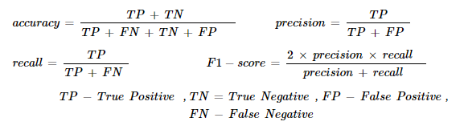

```python
from sklearn.model_selection import StratifiedKFold
from sklearn.metrics import accuracy_score, recall_score, f1_score

# Definicja funkcji evaluate_model, która ocenia wybrany model za pomocą walidacji krzyżowej
# model - model do oceny
# X - cechy niezależne
# Y - cechy zależne
# n_splits - liczba podziałów w walidacji krzyżowej (domyślnie 5)
# accF - funkcja do obliczenia dokładności (domyślnie accuracy_score)
# recF - funkcja do obliczenia recall (domyślnie recall_score)
def evaluate_model(model, X, Y, n_splits=5, accF=accuracy_score, recF=recall_score):
    # Inicjalizacja obiektu StratifiedKFold do walidacji krzyżowej
    skf = StratifiedKFold(n_splits=n_splits)
    acc = 0  # Inicjalizacja zmiennej przechowującej sumę dokładności dla wszystkich podziałów
    rec = 0  # Inicjalizacja zmiennej przechowującej sumę miary odzysku dla wszystkich podziałów
    f1 = 0   # Inicjalizacja zmiennej przechowującej sumę F1-score dla wszystkich podziałów

    # Pętla po podziałach danych w walidacji krzyżowej
    for train_index, test_index in skf.split(X, Y):
        x_train, x_test = X[train_index], X[test_index]  # Podział danych na zbiory treningowy i testowy w walidacji krzyżowej
        y_train, y_test = Y[train_index], Y[test_index]  # Podział etykiet klas na zbiory treningowy i testowy w walidacji krzyżowej

        model.fit(x_train, y_train)

        # Przewidywanie etykiet klas dla danych testowych
        y_pred = model.predict(x_test)

        # Obliczenie dokładności i miary odzysku dla bieżącego podziału
        acc_current = accF(y_test, y_pred)
        acc += acc_current
        rec_current = recF(y_test, y_pred)
        rec += rec_current

        # Obliczenie F1-score dla bieżącego podziału
        f1 += f1_score(y_test, y_pred)

    # Obliczenie średniej dokładności, miary odzysku i F1-score ze wszystkich podziałów walidacji krzyżowej
    acc /= n_splits
    rec /= n_splits
    f1 /= n_splits

    # Wyświetlenie wyników oceny modelu
    print('Dokładność: ', acc)
    print('Recall: ', rec)
    print('F1-score: ', f1)

    # Zwrócenie dokładności, miary odzysku i F1-score
    return acc, rec, f1
```

```python
from matplotlib.colors import LogNorm, Normalize

def final_eval(model):

    #Wyliczenie metryk
    y_pred = model.predict(X_scaled_test)
    acc = accuracy_score(Y_test, y_pred)
    rec = recall_score(Y_test, y_pred)
    f1 = f1_score(Y_test, y_pred)

    # Wyświetlenie confusion matrix
    cf_matrix = confusion_matrix(Y_train, y_sgd_pred)
    sns.heatmap(cf_matrix, square=True, norm=LogNorm())

    # Wyświetlenie wyników oceny modelu
    print('Precyzja: ', acc)
    print('Recall: ', rec)
    print('F1-score: ', f1)
```

# 1. Logistic Regression

Regresja logistyczna – jedna z metod regresji używanych w statystyce w przypadku, gdy zmienna zależna jest na skali dychotomicznej (przyjmuje tylko dwie wartości). Zmienne niezależne w analizie regresji logistycznej mogą przyjmować charakter nominalny, porządkowy, przedziałowy lub ilorazowy. W przypadku zmiennych nominalnych oraz porządkowych następuje ich przekodowanie w liczbę zmiennych zero-jedynkowych taką samą lub o 1 mniejszą niż liczba kategorii w jej definicji.

Zwykle wartości zmiennej objaśnianej wskazują na wystąpienie lub brak wystąpienia pewnego zdarzenia, które chcemy prognozować. Regresja logistyczna pozwala wówczas na obliczanie prawdopodobieństwa tego zdarzenia (tzw. prawdopodobieństwo sukcesu).

Formalnie model regresji logistycznej jest uogólnionym modelem liniowym (GLM), w którym użyto logitu jako funkcji wiążącej.

```python
from sklearn.linear_model import LogisticRegression

# Utworzenie obiektu logistic_model klasy LogisticRegression do modelowania regresji logistycznej
logistic_model = LogisticRegression()

# Wywołanie funkcji evaluate_model do oceny modelu regresji logistycznej
# X_scaled_train - przeskalowane cechy danych treningowych
# Y_train - etykiety klas treningowych
# acc_LogisticRegression, rec_LogisticRegression, f1_LogisticRegression - wyniki oceny modelu (dokładność, recall, F1-score)
acc_LogisticRegression, rec_LogisticRegression, f1_LogisticRegression = evaluate_model(logistic_model, X_scaled_train, Y_train)
```

```
Dokładność:  0.9991968224011938
Recall:  0.6218760142810776
F1-score:  0.7265650261774097
```

# 2. SGD Classifier

SGD Classifier (Stochastic Gradient Descent Classifier) jest modelem uczenia maszynowego, który należy do rodziny klasyfikatorów liniowych. Jest to elastyczny i wydajny klasyfikator, który dobrze radzi sobie z dużymi zestawami danych, co czyni go idealnym wyborem dla projektów z analizy danych.

Główne cechy modelu SGD Classifier to:

- Efektywność obliczeniowa: Wykorzystuje metodę optymalizacji stochastycznego spadku gradientu, co umożliwia szybkie dostosowywanie modelu do dużych zbiorów danych. Dzięki temu jest wydajny nawet w przypadku bardzo dużych zbiorów danych.
- Wielozadaniowość: Może być stosowany zarówno do problemów klasyfikacji binarnej, jak i wieloklasowej. Jest to bardzo elastyczny klasyfikator, który można dostosować do różnych scenariuszy biznesowych.
- Regularyzacja: Posiada wbudowane opcje regularyzacji, co pomaga w zapobieganiu przeuczeniu i poprawia ogólną zdolność generalizacji modelu.
- Parametryzacja: Dzięki różnym parametrom, takim jak liczba iteracji, stała uczenia czy funkcja straty, model można dostosować do konkretnej analizy danych i problemu klasyfikacji.

SGD Classifier jest używany w projekcie z metod analizy danych ze względu na swoją wszechstronność, wydajność i możliwość dostosowania do różnorodnych zadań klasyfikacji. Jego zastosowanie może prowadzić do skutecznych i skalowalnych rozwiązań w analizie danych.

# Confusion Matrix dla SGD Classifier

Macierz pomyłek (confusion matrix) to tabela używana w analizie klasyfikacji, która pokazuje liczbę poprawnych i błędnych klasyfikacji wykonanych przez model predykcyjny na zestawie danych testowych. Składa się z czterech komórek, które reprezentują liczbę prawdziwie pozytywnych (True Positive), fałszywie pozytywnych (False Positive), prawdziwie negatywnych (True Negative) i fałszywie negatywnych (False Negative). Ta struktura pozwala na ocenę wydajności modelu klasyfikacji.

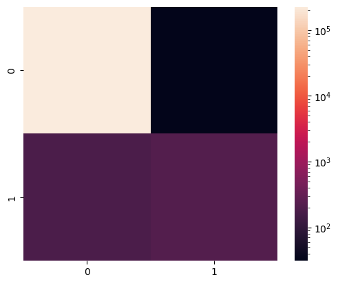

```python
from sklearn.linear_model import SGDClassifier
from sklearn.model_selection import cross_val_predict
from sklearn.metrics import confusion_matrix


# Utworzenie obiektu sgd_clf klasy SGDClassifier do klasyfikacji za pomocą metody SGD
# max_iter=1000 - maksymalna liczba iteracji optymalizacji
# tol=1e-3 - kryterium zatrzymania optymalizacji
# random_state=42 - ustawienie wartości random_state dla powtarzalności wyników
sgd_clf = SGDClassifier(max_iter=1000, tol=1e-3, random_state=42)

# Wykonanie predykcji za pomocą walidacji krzyżowej (cv=3) i zwrócenie predykcji dla każdej próbki
y_sgd_pred = cross_val_predict(sgd_clf, X_scaled_train, Y_train, cv = 3)

# Obliczenie macierzy pomyłek dla prawdziwych etykiet klas (Y_train) i przewidywanych etykiet klas (y_sgd_pred)
cf_matrix = confusion_matrix(Y_train, y_sgd_pred)
sns.heatmap(cf_matrix, square=True, norm=LogNorm())
```

```python
# Utworzenie obiektu model klasy SGDClassifier do klasyfikacji za pomocą metody SGD
# max_iter=1000 - maksymalna liczba iteracji optymalizacji
# tol=1e-3 - kryterium zatrzymania optymalizacji
# random_state=42 - ustawienie wartości random_state dla powtarzalności wyników
model = SGDClassifier(max_iter=1000, tol=1e-3, random_state=42)

# Wywołanie funkcji evaluate_model do oceny modelu klasyfikatora SGD
# X_scaled_train - przeskalowane cechy danych treningowych
# Y_train - etykiety klas treningowych
# acc_SGDClassifier, rec_SGDClassifier, f1_SGDClassifier - wyniki oceny modelu (dokładność, recall, F1-score)
acc_SGDClassifier, rec_SGDClassifier, f1_SGDClassifier = evaluate_model(model, X_scaled_train, Y_train)
```

```
Dokładność:  0.9991134323772741
Recall:  0.5711781888997078
F1-score:  0.6888752896444964
```

# 3. K-Nearest Neighbors (KNN)

Algorytm k najbliższych sąsiadów (lub algorytm k-nn z ang. k nearest neighbours) – jeden z algorytmów regresji nieparametrycznej używanych w statystyce do prognozowania wartości pewnej zmiennej losowej. Może również być używany do klasyfikacji.

## Założenia:

- Dany jest zbiór uczący zawierający obserwacje, z których każda ma przypisany wektor zmiennych objaśniających

oraz wartość zmiennej objaśnianej.

- Dana jest obserwacja z przypisanym wektorem zmiennych objaśniających, dla której chcemy prognozować wartość zmiennej objaśnianej.

## Algorytm polega na:

- porównaniu wartości zmiennych objaśniających dla obserwacji z wartościami tych zmiennych dla każdej obserwacji w zbiorze uczącym.
- wyborze (ustalona z góry liczba) najbliższych do obserwacji ze zbioru uczącego.
- uśrednieniu wartości zmiennej objaśnianej dla wybranych obserwacji, w wyniku czego uzyskujemy prognozę.

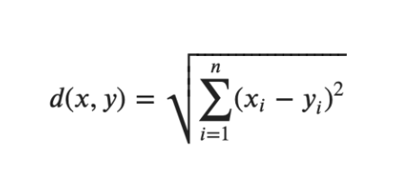

```python
from sklearn.model_selection import StratifiedKFold
from sklearn.neighbors import KNeighborsClassifier
from sklearn.metrics import accuracy_score, recall_score, f1_score

# Ustawienie liczby sąsiadów na 5
k = 5

# Utworzenie obiektu model klasy KNeighborsClassifier do klasyfikacji za pomocą metody k-najbliższych sąsiadów
model = KNeighborsClassifier(n_neighbors=k)

# Wywołanie funkcji evaluate_model do oceny modelu klasyfikatora k-najbliższych sąsiadów
# X_scaled_train - przeskalowane cechy danych treningowych
# Y_train - etykiety klas treningowych
# acc_KNN, rec_KNN, f1_KNN - wyniki oceny modelu (dokładność, recall, F1-score)
acc_KNN, rec_KNN, f1_KNN = evaluate_model(model, X_scaled_train, Y_train)
```

```
Dokładność:  0.9994294366784437
Recall:  0.7385913664394679
F1-score:  0.8177091489260508
```

# GridSearchCV

GridSearchCV to technika optymalizacji hiperparametrów, która polega na przeszukiwaniu przestrzeni hiperparametrów w celu znalezienia najlepszej kombinacji dla danego modelu. Jest to potężne narzędzie w analizie danych, które pomaga w wyborze optymalnych parametrów modelu, co prowadzi do poprawy jego wydajności i skuteczności.

Główne cechy techniki GridSearchCV to:

- Przeszukiwanie siatki: GridSearchCV przeszukuje określoną siatkę wartości parametrów, które zdefiniowano wcześniej. Możliwe wartości parametrów są określone przez użytkownika i obejmują różne kombinacje, które chcemy zbadać.
- Walidacja krzyżowa: GridSearchCV używa techniki walidacji krzyżowej do oceny skuteczności każdej kombinacji hiperparametrów. Jest to istotne, aby uniknąć nadmiernej optymalizacji (overfittingu) do konkretnego zestawu danych.
- Optymalizacja hiperparametrów: Celem GridSearchCV jest znalezienie takich wartości hiperparametrów, które maksymalizują wybraną metrykę oceny modelu, w naszym przypadku Recall.
- Dostrojenie modelu: GridSearchCV umożliwia dostrojenie różnych modeli, w tym LogisticRegression, SGD Classifier czy KNN, co pozwala na uzyskanie optymalnych wyników w zależności od charakteru danych i problemu.
- GridSearchCV jest używany w projekcie do optymalizacji hiperparametrów modeli, co pomaga w znalezieniu najlepszych kombinacji parametrów i poprawia skuteczność klasyfikacji. Jest to istotny krok w procesie tworzenia modeli w analizie danych, który może znacząco wpłynąć na wyniki predykcyjne i jakość rozwiązania.

## 4. Logistic Regression with GridSearchCV

```python
from sklearn.model_selection import GridSearchCV

# Utworzenie obiektu grid_LG klasy GridSearchCV do przeszukiwania siatki hiperparametrów dla modelu regresji logistycznej
# estimator=LogisticRegression(max_iter=1000) - model bazowy, w tym przypadku regresja logistyczna z maksymalną liczbą iteracji 1000
# param_grid={'class_weight': [{0: 1, 1: v} for v in range(1, 4)]} - siatka hiperparametrów, w tym wagi klas dla klas 0 i 1
# scoring='recall' - wybór miary do oceny modelu, w tym przypadku recall (miara odzysku)
# cv=2 - liczba podziałów w walidacji krzyżowej
# verbose=2 - poziom szczegółowości wyjścia podczas dopasowywania modelu
# n_jobs=-1 - liczba zadań do równoległego wykonywania, -1 oznacza wykorzystanie wszystkich dostępnych rdzeni CPU
grid_LG = GridSearchCV(
    estimator=LogisticRegression(max_iter=1000),
    param_grid={'class_weight': [{0: 1, 1: v} for v in range(1, 4)]},
    scoring='recall',
    cv=2,
    verbose=2,
    n_jobs=-1
)

# Dopasowanie siatki hiperparametrów do danych treningowych i wybór najlepszego estymatora
model_gridLG = grid_LG.fit(X_scaled_train, Y_train).best_estimator_

# Ocena najlepszego estymatora za pomocą funkcji evaluate_model
# acc_gridLogisticRegression, rec_gridLogisticRegression, f1_gridLogisticRegression - wyniki oceny modelu (dokładność, miara odzysku, F1-score)
acc_gridLogisticRegression, rec_gridLogisticRegression, f1_gridLogisticRegression = evaluate_model(model_gridLG, X_scaled_train, Y_train)
```

```
Fitting 2 folds for each of 3 candidates, totalling 6 fits
Dokładność:  0.9992714345278587
Recall:  0.7615709185329438
F1-score:  0.782735732792678
```

## 5. SGD Classifier with GridSearchCV

```python
from sklearn.model_selection import GridSearchCV

# Utworzenie obiektu grid_SGDC klasy GridSearchCV do przeszukiwania siatki hiperparametrów dla modelu klasyfikatora SGD
# estimator=SGDClassifier(max_iter=1000, tol=1e-3, random_state=42) - model bazowy, klasyfikator SGD z maksymalną liczbą iteracji 1000, tolerancją 1e-3 i stanem losowym 42
# param_grid - siatka hiperparametrów do przeszukania, w tym współczynniki alpha, funkcje straty i kary
# scoring='recall' - wybór miary do oceny modelu, w tym przypadku recall (miara odzysku)
# cv=2 - liczba podziałów w walidacji krzyżowej
# verbose=2 - poziom szczegółowości wyjścia podczas dopasowywania modelu
# n_jobs=-1 - liczba zadań do równoległego wykonywania, -1 oznacza wykorzystanie wszystkich dostępnych rdzeni CPU
grid_SGDC = GridSearchCV(
    estimator=SGDClassifier(max_iter=1000, tol=1e-3, random_state=42),
    param_grid={
        'alpha': [1e-4, 1e-3, 1e-2, 1e-1, 1e0, 1e1, 1e2, 1e3],
        'loss': ['hinge', 'log_loss'],
        'penalty': ['l2', 'elasticnet']
    },
    scoring='recall',
    cv=2,
    verbose=2,
    n_jobs=-1
)

# Dopasowanie siatki hiperparametrów do danych treningowych i wybór najlepszego estymatora
best_estimator_SGD = grid_SGDC.fit(X_scaled_train, Y_train).best_estimator_

# Ocena uzyskanego estymatora za pomocą funkcji evaluate_model
# acc_gridSGDClassifier, rec_gridSGDClassifier, f1_gridSGDClassifier - wyniki oceny modelu (dokładność, miara odzysku, F1-score)
acc_gridSGDClassifier, rec_gridSGDClassifier, f1_gridSGDClassifier = evaluate_model(best_estimator_SGD, X_scaled_train, Y_train)

# Wyświetlenie najlepszych parametrów uzyskanych w trakcie przeszukiwania siatki hiperparametrów
grid_SGDC.best_params_
```

```
Fitting 2 folds for each of 32 candidates, totalling 64 fits
Dokładność:  0.9991090434286466
Recall:  0.5737098344693281
F1-score:  0.6890283909930413
```

```
{'alpha': 0.0001, 'loss': 'hinge', 'penalty': 'elasticnet'}
```

## 6. K-Nearest Neighbors with GridSearchCV

```python
from sklearn.model_selection import GridSearchCV

# Utworzenie obiektu grid_KNN klasy GridSearchCV do przeszukiwania siatki hiperparametrów dla modelu klasyfikatora k-najbliższych sąsiadów
# estimator=KNeighborsClassifier(n_neighbors=k) - model bazowy, klasyfikator k-najbliższych sąsiadów z ustaloną liczbą sąsiadów k
# param_grid - siatka hiperparametrów do przeszukania, w tym liczba sąsiadów
# scoring='recall' - wybór miary do oceny modelu, w tym przypadku recall (miara odzysku)
# cv=2 - liczba podziałów w walidacji krzyżowej
# verbose=2 - poziom szczegółowości wyjścia podczas dopasowywania modelu
# n_jobs=-1 - liczba zadań do równoległego wykonywania, -1 oznacza wykorzystanie wszystkich dostępnych rdzeni CPU
grid_KNN = GridSearchCV(
    estimator=KNeighborsClassifier(n_neighbors=k),
    param_grid={'n_neighbors': [3, 5, 8, 15, 25, 50]},
    scoring='recall',
    cv=2,
    verbose=2,
    n_jobs=-1
)

# Dopasowanie siatki hiperparametrów do danych treningowych i wybór najlepszego estymatora
model_gridKNN = grid_KNN.fit(X_scaled_train, Y_train).best_estimator_

# Ocena uzyskanego estymatora za pomocą funkcji evaluate_model
# acc_gridKNN, rec_gridKNN, f1_gridKNN - wyniki oceny modelu (dokładność, miara odzysku, F1-score)
acc_gridKNN, rec_gridKNN, f1_gridKNN = evaluate_model(model_gridKNN, X_scaled_train, Y_train)

# Wyświetlenie najlepszych parametrów uzyskanych w trakcie przeszukiwania siatki hiperparametrów
grid_KNN.best_params_
```

```
Fitting 2 folds for each of 6 candidates, totalling 12 fits
Dokładność:  0.9993372687572692
Recall:  0.7462187601428109
F1-score:  0.7957293924940985
```

```
{'n_neighbors': 25}
```

# 7. Hybrid Model (Voting Classifier)

Hybrydowy model, znany także jako Voting Classifier, to technika łączenia wielu modeli w celu poprawy skuteczności klasyfikacji. W przypadku tego projektu łączymy regresję logistyczną i KNN (K-Nearest Neighbors) w ramach jednego modelu, aby wykorzystać moc obu podejść.

Główne cechy hybrydowego modelu (Voting Classifier) to:

- Łączenie różnych podejść: Model ten łączy regresję logistyczną i KNN, wykorzystując ich różne cechy i siły w celu uzyskania bardziej zrównoważonej i wszechstronnej skuteczności klasyfikacji.
- Zespołowa decyzja: W hybrydowym modelu, każdy z modeli (regresja logistyczna i KNN) oddzielnym głosuje na predykcje. Ostateczna decyzja klasyfikacyjna jest podejmowana poprzez głosowanie większościowe lub średnią wagową predykcji wszystkich modeli.
- Zrównoważona skuteczność: Poprzez łączenie różnych modeli, hybrydowy model może osiągnąć bardziej zrównoważoną skuteczność.
- Redukcja ryzyka: W przypadku, gdy jeden z modeli zawodzi lub ma słabą wydajność w określonych przypadkach, hybrydowy model może zredukować ryzyko poprzez uwzględnienie predykcji innych modeli.

Hybrydowy model (Voting Classifier), łączący regresję logistyczną i KNN, jest używany w projekcie jako podejście do zwiększenia skuteczności klasyfikacji poprzez wykorzystanie różnych metod. Jego elastyczność i zdolność do zrównoważonej oceny przypadków czynią go atrakcyjnym narzędziem w analizie danych.

```python
from sklearn.ensemble import VotingClassifier

# Utworzenie obiektu hybrid_model klasy VotingClassifier, który agreguje modele model_gridLG i model_gridKNN
# estimators - lista estymatorów, w tym modeli regresji logistycznej i klasyfikatora k-najbliższych sąsiadów
# voting='soft' - tryb głosowania, głosowanie miękkie
hybrid_model = VotingClassifier(
    estimators=[
        ('LG', model_gridLG),
        ('KNN', model_gridKNN)
    ],
    voting='soft'
)

# Ocena hybrydowego modelu za pomocą funkcji evaluate_model
# acc_hybrid, rec_hybrid, f1_hybrid - wyniki oceny modelu (dokładność, miara odzysku, F1-score)
acc_hybrid, rec_hybrid, f1_hybrid = evaluate_model(hybrid_model, X_scaled_train, Y_train)
```

```
Dokładność:  0.9994162698325615
Recall:  0.7741966893865628
F1-score:  0.82096961956177
```